# zlepki_DLA

### Dyfuzyjny wzrost zlepków

Symulacje dyfuzyjnego wzrostu zlepka możemy przeprowadzić na sieci kwadratowej w następujący sposób

```python
import random
import numpy as np
import matplotlib.pyplot as plt

v=np.array([[1, 0],[0, 1],[-1, 0],[0,-1]]) # 4 wektory do najbliższych sąsiadów

Lp=300  # współrzędna środka sieci
L=2*Lp  # rozmiar liniowy sieci
siec=np.zeros((L,L),int)  # siec o  L*L pocżatkowo wyzerowana
#  Składowe sieci mogą przyjmować wartości -1, 0,1 i 2
# Wartości te reprezentują
#  -1 węzły obwodu
#   0 węzły dyfuzyjne
#   1 węzły zlepka
#   2 węzły pochlaniające

def init():
    siec[Lp,Lp]=1  #zarodek
    mod_obwodu(Lp,Lp)
    #wezly pochlaniajace
    for i in range(L):
        siec[i,0]=2
        siec[i,L-1]=2
        siec[0,i]=2
        siec[L-1,i]=2
    return np.array([Lp,Lp],int)


def start_cz(R):
    kat=2*np.pi*random.random()
    # losowe położenie początkowe na okręgu o promieniu R
    return np.array([Lp+np.rint(R*np.cos(kat)),Lp+np.rint(R*np.sin(kat))],int)

def mod_obwodu(x,y):
    for i in range(4):
        if siec[x+v[i,0],y+v[i,1]]==0:
            siec[x+v[i,0],y+v[i,1]]=-1

def spacer_los(R):
    #położenie początkowe na okręgu o promieniu R
    r=start_cz(R)
    while siec[r[0],r[1]]==0:
        r=r+v[random.randint(0,3)] #losowy  krok
    return siec[r[0],r[1]], r

def wzrost(R,mmax,xy_z):
    licz=1
    rb=init()
    xy_z.append(rb)
    while licz<mmax:
        status,rb=spacer_los(R)
        if status==-1:
            siec[rb[0],rb[1]]=1
            mod_obwodu(rb[0],rb[1])
            xy_z.append(rb)
            licz+=1



def rys_zlep(kn,xy):
    fig, ax=plt.subplots()
    xt, yt = zip(*xy)
    xf=xt[:kn]
    yf=yt[:kn]
    mn=min(min(xf),min(yf))
    mx=max(max(xf),max(yf))
    dm=np.rint((mx-mn)/4)
    if dm <1:
        dm=1
    ax.set_xticks(np.arange(mn-dm,mx+dm,dm))
    ax.set_yticks(np.arange(mn-dm,mx+dm,dm))
    zlep=ax.scatter(xf,yf,s=6,c='r')
    ax.set_ylabel('y')
    ax.set_xlabel('x')
    tytul = "Zlepek o masie =" +str(kn)
    ax.set_title(tytul)
    plt.axis('equal')
    plt.show()
```

```python
xy_agr=[]

mmax=1000
R=150
wzrost(R,mmax,xy_agr)
```

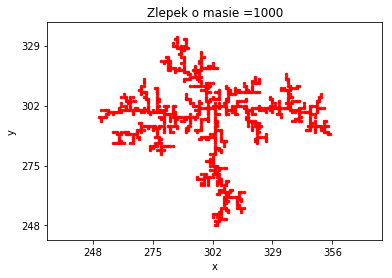

```python
rys_zlep(1000,xy_agr)
```

Symulacje wzrostu dużego zlepka są czasochłonne. Dlatego warto zapisać wyniki symulacji do pliku, żeby je póżniej analizować.

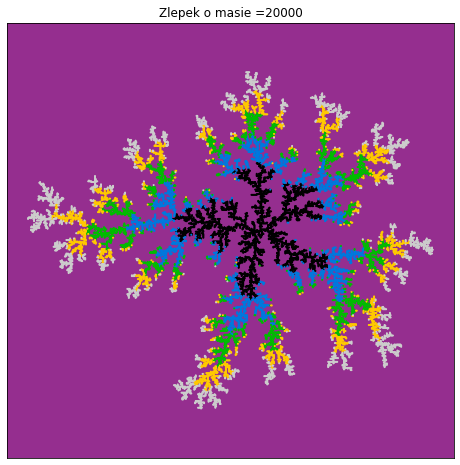

```python
wej=open('test_zl20.txt','r')
lines=wej.readlines()
wej.close()
xt=[]
yt=[]
for line in lines:
    tym=line.split()
    xt.append(float(tym[0]))
    yt.append(float(tym[1]))
xa=np.array(xt)
ya=np.array(yt)

import matplotlib.cm as cm

plt.rcParams['figure.figsize'] = 8, 8
fig, ax = plt.subplots()
ax = plt.gca()
ax.set_facecolor('xkcd:warm purple') #dark sand
ax.axes.get_xaxis().set_visible(False)
ax.axes.get_yaxis().set_visible(False)
mn=min(min(xa),min(ya))
mx=max(max(xa),max(ya))
dm=np.rint((mx-mn)/10)
h = ax.axis([mn-dm,mx+dm,mn-dm,mx+dm])
masa=len(xa)
licz_kol=5  # liczba kolorow
mfazy=int(masa/licz_kol)

tabkol=np.fromfunction(lambda i:np.floor(i/(mfazy+1)) ,(masa,),dtype=int)

zb2=ax.scatter(xa,ya,s=1,c=tabkol,cmap=cm.nipy_spectral)
#cm.hsv, cm.nipy_spectral, cm.rainbow, , cm.gist_rainbow
tyt="Zlepek o masie ="+str(len(xa))
ax.set_title(tyt)
plt.axis('equal')
plt.show()
```

Oznaczenie kolejnych faz wzrostu kolorami pokazuje, że nowe cząstki bardzo rzadko przyłączają się głębiej niż na najbardziej wystających odnogach. Wynika to z natury błądzenia losowego. Otrzymany zlepek ma strukturę fraktalną.

#### Wzrost zlepka na obwodzie koła.

Zarodki rozmieszczone są na okręgu o promieniu R. Kolejne cząstki startują ze środka koła, poruszając się losowo po węzłach sieci. Gdy cząstka dotrze do obwodu zlepka zostaje do niego przyłączona.

```python
LCp=120  # współrzędna środka sieci
LC=2*LCp  # rozmiar liniowy sieci
circle=np.zeros((LC,LC),int)  # siec o  L*L pocżatkowo wyzerowana
#  Składowe sieci mogą przyjmować wartości -1, 0,1 i 2
# Wartości te reprezentują
#  -1 węzły obwodu
#   0 węzły dyfuzyjne
#   1 węzły zlepka


def initC(Rc):
    Rc2=Rc**2
    for i in range(LC):
        for k in range(LC):
            if ((i-LCp)**2+(k-LCp)**2)>=Rc2:
                circle[i,k]=1  #zarodek
    for i in range(1,LC-1):
        for k in range(1,LC-1):
            if n_sas(i,k)>0:
                circle[i,k]=-1

def n_sas(x,y):
    licz=0
    if circle[x,y]==0:
        for i in range(4):
            if circle[x+v[i,0],y+v[i,1]]==1:
                licz+=1
    return licz


def start_C():
    return np.array([LCp,LCp],int)

def mod_obwC(x,y):
    for i in range(4):
        if circle[x+v[i,0],y+v[i,1]]==0:
            circle[x+v[i,0],y+v[i,1]]=-1

def spacer_C():
    #położenie początkowe na okręgu o promieniu R
    r=start_C()
    while circle[r[0],r[1]]==0:
        r=r+v[random.randint(0,3)] #losowy  krok
    return circle[r[0],r[1]], r

def wzrost_C(R,mmax,xy_z):
    licz=0
    rb=initC(R)

    while licz<mmax:
        status,rb=spacer_C()
        if status==-1:
            circle[rb[0],rb[1]]=1
            mod_obwC(rb[0],rb[1])
            xy_z.append(rb)
            licz+=1
        if licz%500==0:
            print(licz)




def rys_zlep(kn,xy):
    fig, ax=plt.subplots()
    xt, yt = zip(*xy)
    xf=xt[:kn]
    yf=yt[:kn]
    mn=min(min(xf),min(yf))
    mx=max(max(xf),max(yf))
    dm=np.rint((mx-mn)/4)
    if dm <1:
        dm=1
    ax.set_xticks(np.arange(mn-dm,mx+dm,dm))
    ax.set_yticks(np.arange(mn-dm,mx+dm,dm))
    zlep=ax.scatter(xf,yf,s=5,c='r')
    ax.set_ylabel('y')
    ax.set_xlabel('x')
    tytul = "Zlepek o masie =" +str(kn)
    ax.set_title(tytul)
    plt.axis('equal')
    plt.show()

xy_c=[]
mmaxC=3500
wzrost_C(110,mmaxC,xy_c)
```

```
500
1000
1500
2000
2500
3000
3500
```

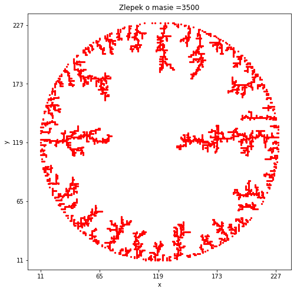

```python
rys_zlep(3500,xy_c)
```

### Model Edena

Prosty model zaproponowany przez Edena do symulacji wzrostu kolonii komórkowych.

W tym modelu zaczynamy od umieszczenia zarodka w środku sieci. Niezajęte sąsiednie węzły tworzą obwód zlepka. W najprostszej wersji modelu nowa cząstka jest dołączana do losowo wybranego węzła z obwodu zlepka. Dołączenie nowej cząstki modyfikuje obwód. Taki proces wzrostu jest powtarzany tak długo aż zlepek osiągnie brzeg sieci.

```python
def rys_zlep(kn):
#4 wektory do najbliższych sąsiadów
    v=np.array([[1, 0],[0, 1],[-1, 0],[0,-1]])
    Lp=500
    L=2*Lp
    siec=np.zeros((L,L),int)

    zlep_x=[]
    zlep_y=[]
#zarodek
    r=np.array([0,0])
    lista=[[Lp,Lp]]
    for k in range (kn):
        r=random.choice(lista)
        if (r[0]==0)or(r[0]==L-1):
            break
        if (r[1]==0)or(r[1]==L-1):
            break
        siec[r[0],r[1]]=1
        zlep_x.append(r[0])
        zlep_y.append(r[1])
        for i in range(4):
            rs=r+v[i]
            if(siec[rs[0],rs[1]]==0):
                lista.append([rs[0],rs[1]])
        lista.remove([r[0],r[1]])

    plt.rcParams['figure.figsize'] = 8, 8
    fig, ax=plt.subplots()
    ax = plt.gca()
    ax.set_facecolor('xkcd:dark sand') #  warm purple
    ax.axes.get_xaxis().set_visible(False)
    ax.axes.get_yaxis().set_visible(False)
    mn=min(min(zlep_x),min(zlep_y))
    mx=max(max(zlep_x),max(zlep_y))
    dm=np.rint((mx-mn)/10)
    h = ax.axis([mn-dm,mx+dm,mn-dm,mx+dm])
    masa=len(zlep_x)
    licz_kol=10  # liczba kolorow
    mfazy=int(masa/licz_kol)

    tabkol=np.fromfunction(lambda i:np.floor(i/(mfazy+1)) ,(masa,),dtype=int)

    zb2=ax.scatter(zlep_x,zlep_y,s=1,c=tabkol,cmap=cm.nipy_spectral)
    #cm.hsv, cm.nipy_spectral, cm.rainbow, , cm.gist_rainbow
    tyt="Zlepek Edena o masie ="+str(len(zlep_x))
    ax.set_title(tyt)
    plt.axis('equal')
    plt.show()
```

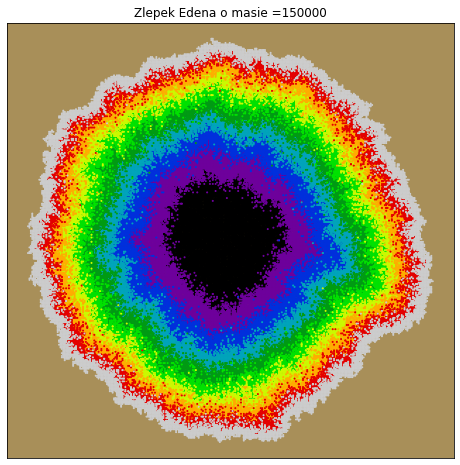

```python
rys_zlep(150000)
```

Zlepek Edena ma zwartą strukturę, zupełnie inną niż zlepek DLA